# ML Modeling (Week 3, HW 1)

Ilana Radinsky

June 26, 2017

# 1. Let’s simulate some data, so that we can practice forecasting with LASSO & Ridge.

1. First, let’s simulate a design matrix (X) with N = 100 data points, each with K = 100 normally distributed covariates (look up the matrix and rnorm functions).
2. Second, let’s simulate a K x 1 matrix of coefficients (B) and a N x 1 matrix of error terms (e) each from a normal distribution.
3. Now let us calculate our observed outcomes as: Y = X * B + e.

```r
k <- 100
N <- 100

X <- matrix(rnorm(n=N*k, mean=0, sd=1), N, k)
B <- matrix(rnorm(n=1*k, mean=0, sd=1), k, 1)
e <- matrix(rnorm(n=1*N, mean=0, sd=1), N, 1)

Y <- X %*% B + e
```

4. This is our training data, use cv:glmnet() to train a Ridge, LASSO and OLS model on this data.

```r
X_df <- data.frame(X)
Y_df <- data.frame(Y)

ols <- glm(Y_df$Y ~ ., data=X_df)
summary(ols)
```

```
##
## Call:
## glm(formula = Y_df$Y ~ ., data = X_df)
##
## Deviance Residuals:
##   [1]  0  0  0  0  0  0  0  0  0  0  0  0  0  0  0  0  0  0  0  0  0  0  0
##  [24]  0  0  0  0  0  0  0  0  0  0  0  0  0  0  0  0  0  0  0  0  0  0  0
##  [47]  0  0  0  0  0  0  0  0  0  0  0  0  0  0  0  0  0  0  0  0  0  0  0
##  [70]  0  0  0  0  0  0  0  0  0  0  0  0  0  0  0  0  0  0  0  0  0  0  0
##  [93]  0  0  0  0  0  0  0  0
##
## Coefficients: (1 not defined because of singularities)
##              Estimate Std. Error t value Pr(>|t|)
## (Intercept)  -3.38746         NA      NA       NA
## X1           -7.11595         NA      NA       NA
## X2           10.44798         NA      NA       NA
## X3           18.08458         NA      NA       NA
## X4           12.42066         NA      NA       NA
## X5          -24.93640         NA      NA       NA
## X6           -9.31523         NA      NA       NA
## X7            7.89330         NA      NA       NA
## X8            2.36566         NA      NA       NA
## X9           -0.63290         NA      NA       NA
## X10          12.25379         NA      NA       NA
## X11           1.67156         NA      NA       NA
## X12           7.11561         NA      NA       NA
## X13           8.54083         NA      NA       NA
## X14          -1.86744         NA      NA       NA
## X15           4.52964         NA      NA       NA
## X16          13.84263         NA      NA       NA
## X17          14.22733         NA      NA       NA
## X18          -7.61412         NA      NA       NA
## X19          14.94018         NA      NA       NA
## X20          -2.56393         NA      NA       NA
## X21           3.16389         NA      NA       NA
## X22          29.22020         NA      NA       NA
## X23           9.70111         NA      NA       NA
## X24         -17.66670         NA      NA       NA
## X25          13.67908         NA      NA       NA
## X26          -3.90175         NA      NA       NA
```

[output cut: 67 more lines]

```
## X94         -14.45576         NA      NA       NA
## X95          -5.77272         NA      NA       NA
## X96          -7.66440         NA      NA       NA
## X97         -14.96926         NA      NA       NA
## X98          -3.97867         NA      NA       NA
## X99           8.87327         NA      NA       NA
## X100               NA         NA      NA       NA
##
## (Dispersion parameter for gaussian family taken to be NaN)
##
##     Null deviance: 9.8271e+03  on 99  degrees of freedom
## Residual deviance: 7.8716e-25  on  0  degrees of freedom
## AIC: -5524.9
##
## Number of Fisher Scoring iterations: 1
```

```r
lasso <- cv.glmnet(X, Y, alpha=1)
summary(lasso)
```

```
##            Length Class  Mode
## lambda     48     -none- numeric
## cvm        48     -none- numeric
## cvsd       48     -none- numeric
## cvup       48     -none- numeric
## cvlo       48     -none- numeric
## nzero      48     -none- numeric
## name        1     -none- character
## glmnet.fit 12     elnet  list
## lambda.min  1     -none- numeric
## lambda.1se  1     -none- numeric
```

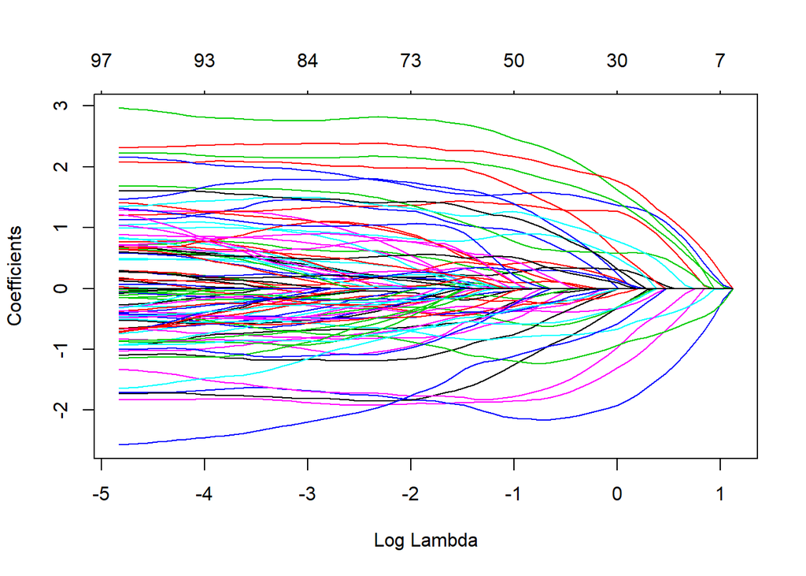

```r
plot(lasso$glmnet.fit, "lambda")
```

```r
ridge <- cv.glmnet(X, Y, alpha=0)
summary(ridge)
```

```
##            Length Class  Mode
## lambda     47     -none- numeric
## cvm        47     -none- numeric
## cvsd       47     -none- numeric
## cvup       47     -none- numeric
## cvlo       47     -none- numeric
## nzero      47     -none- numeric
## name        1     -none- character
## glmnet.fit 12     elnet  list
## lambda.min  1     -none- numeric
## lambda.1se  1     -none- numeric
```

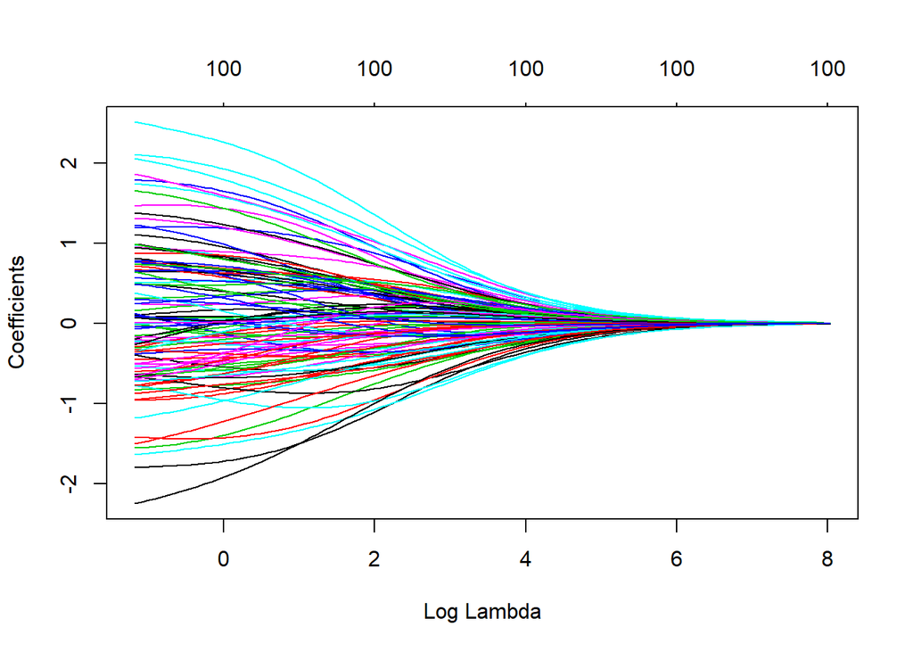

```r
plot(ridge$glmnet.fit, "lambda")
```

```r
set.seed(17)

sample_size <- floor(0.90 * nrow(X))
inx <- sample(seq_len(nrow(X)), size=sample_size)

X_train <- X[inx, ]
X_test <- X[-inx, ]

Y_train <- Y[inx, ]
Y_test <- Y[-inx, ]
```

OLS

```r
X_train_df <- data.frame(X_train)
Y_train_df <- data.frame(Y_train)

X_test_df <- data.frame(X_test)
Y_test_df <- data.frame(Y_test)

ols_new <- glm(Y_train_df$Y_train ~ ., data=X_train_df)
summary(ols_new)
```

```
##
## Call:
## glm(formula = Y_train_df$Y_train ~ ., data = X_train_df)
##
## Deviance Residuals:
##  [1]  0  0  0  0  0  0  0  0  0  0  0  0  0  0  0  0  0  0  0  0  0  0  0
## [24]  0  0  0  0  0  0  0  0  0  0  0  0  0  0  0  0  0  0  0  0  0  0  0
## [47]  0  0  0  0  0  0  0  0  0  0  0  0  0  0  0  0  0  0  0  0  0  0  0
## [70]  0  0  0  0  0  0  0  0  0  0  0  0  0  0  0  0  0  0  0  0  0
##
## Coefficients: (11 not defined because of singularities)
##              Estimate Std. Error t value Pr(>|t|)
## (Intercept) -2.120961         NA      NA       NA
## X1           0.640221         NA      NA       NA
## X2           1.235819         NA      NA       NA
## X3          -1.786120         NA      NA       NA
## X4          -2.090154         NA      NA       NA
## X5           3.436398         NA      NA       NA
## X6          -1.740245         NA      NA       NA
## X7          -1.265226         NA      NA       NA
## X8          -1.204494         NA      NA       NA
## X9           0.600791         NA      NA       NA
## X10          0.159314         NA      NA       NA
## X11         -3.367270         NA      NA       NA
## X12          4.642890         NA      NA       NA
## X13          0.597710         NA      NA       NA
## X14         -0.701347         NA      NA       NA
## X15          1.232212         NA      NA       NA
## X16          1.589504         NA      NA       NA
## X17         -3.387452         NA      NA       NA
## X18          0.571972         NA      NA       NA
## X19          0.539372         NA      NA       NA
## X20          1.999572         NA      NA       NA
## X21          0.330999         NA      NA       NA
## X22          1.221225         NA      NA       NA
## X23          0.576171         NA      NA       NA
## X24          1.768122         NA      NA       NA
## X25         -0.136774         NA      NA       NA
## X26          0.402209         NA      NA       NA
## X27         -2.192922         NA      NA       NA
```

[output cut: 66 more lines]

```
## X94                NA         NA      NA       NA
## X95                NA         NA      NA       NA
## X96                NA         NA      NA       NA
## X97                NA         NA      NA       NA
## X98                NA         NA      NA       NA
## X99                NA         NA      NA       NA
## X100               NA         NA      NA       NA
##
## (Dispersion parameter for gaussian family taken to be NaN)
##
##     Null deviance: 9.1533e+03  on 89  degrees of freedom
## Residual deviance: 2.5439e-26  on  0  degrees of freedom
## AIC: -5271.6
##
## Number of Fisher Scoring iterations: 1
```

```r
y_hat_train <- predict(ols_new, newdata = X_train_df)
mse_train <- mean((y_hat_train-Y_train_df)^2)
mse_train
```

```
## [1] 2.826555e-28
```

```r
y_hat <- predict(ols_new, newdata = X_test_df)
mse_test <- mean((y_hat-Y_test_df)^2)
mse_test
```

```
## [1] 457.0188
```

LASSO

```r
lasso_new <- cv.glmnet(X_train, Y_train, alpha=1)

y_hat_train <- predict(lasso_new, newx=X_train, s="lambda.min")

mse_train <- mean((y_hat_train-Y_train)^2)
mse_train
```

```
## [1] 0.4325542
```

```r
y_hat <- predict(lasso_new, newx=X_test, s="lambda.min")

mse_test <- mean((y_hat-Y_test)^2)
mse_test
```

```
## [1] 22.64033
```

Ridge

```r
ridge_new <- cv.glmnet(X_train, Y_train, alpha=0)

y_hat_train <- predict(ridge_new, newx=X_train, s="lambda.min")

mse_train <- mean((y_hat_train-Y_train)^2)
mse_train
```

```
## [1] 49.66357
```

```r
y_hat <- predict(ridge_new, newx=X_test, s="lambda.min")

mse_test <- mean((y_hat-Y_test)^2)
mse_test
```

```
## [1] 51.65372
```

6. Write a loop to repeat this process for 200 replications and compute the average mean squared error of each estimator across these replications. Which model seems to be working best on the test data? Which models had the biggest change in performance from the training to the test data?

```r
mse.ols.train <- rep(0, 200)
mse.lasso.train <- rep(0, 200)
mse.ridge.train <- rep(0, 200)

mse.ols.test <- rep(0, 200)
mse.lasso.test <- rep(0, 200)
mse.ridge.test <- rep(0, 200)

for (i in 1:200) {
  # Create data
  k <- 100
  N <- 100

  X <- matrix(rnorm(n=N*k, mean=0, sd=1), N, k)
  B <- matrix(rnorm(n=1*k, mean=0, sd=1), k, 1)
  e <- matrix(rnorm(n=1*N, mean=0, sd=1), N, 1)

  Y <- X %*% B + e

  # Separate into test and train sets
  set.seed(17)

  sample_size <- floor(0.90 * nrow(X))
  inx <- sample(seq_len(nrow(X)), size=sample_size)

  X_train <- X[inx, ]
  X_test <- X[-inx, ]

  Y_train <- Y[inx, ]
  Y_test <- Y[-inx, ]

  # Create dataframes for OLS
  X_train_df <- data.frame(X_train)
  X_test_df <- data.frame(X_test)

  Y_train_df <- data.frame(Y_train)
  Y_test_df <- data.frame(Y_test)

  # OLS
  ols <- glm(Y_train_df$Y_train ~ ., data=X_train_df)

  y_hat_train <- predict(ols, newdata = X_train_df)
  y_hat_test <- predict(ols, newdata = X_test_df)

  mse.ols.train[i] <- mean((y_hat_train-Y_train_df)^2)
  mse.ols.test[i] <- mean((y_hat_test-Y_test_df)^2)

  # LASSO
  lasso <- cv.glmnet(X_train, Y_train, alpha=1)

  y_hat_train <- predict(lasso, newx = X_train)
  y_hat_test <- predict(lasso, newx = X_test)

  mse.lasso.train[i] <- mean((y_hat_train-Y_train)^2)
  mse.lasso.test[i] <- mean((y_hat_test-Y_test)^2)

  # Ridge
  ridge <- cv.glmnet(X_train, Y_train, alpha=1)

  y_hat_train <- predict(ridge, newx = X_train)
  y_hat_test <- predict(ridge, newx = X_test)

  mse.ridge.train[i] <- mean((y_hat_train-Y_train)^2)
  mse.ridge.test[i] <- mean((y_hat_test-Y_test)^2)

}
```

[output not shown]

[output cut: 1144 more lines]

[output not shown]

```r
mean.mse.ols.test <- mean(mse.ols.test)
mean.mse.ols.train <- mean(mse.ols.train)

mean.mse.lasso.test <- mean(mse.lasso.test)
mean.mse.lasso.train <- mean(mse.lasso.train)

mean.mse.ridge.test <- mean(mse.ridge.test)
mean.mse.ridge.train <- mean(mse.ridge.train)

print(mean.mse.ols.train)
```

```
## [1] 3.294784e-28
```

```r
print(mean.mse.ols.test)
```

```
## [1] 1523.272
```

```r
print(mean.mse.lasso.train)
```

```
## [1] 0.8478035
```

```r
print(mean.mse.lasso.test)
```

```
## [1] 62.14901
```

```r
print(mean.mse.ridge.train)
```

```
## [1] 5.758153
```

```r
print(mean.mse.ridge.test)
```

```
## [1] 70.13282
```

```r
# Create data
  k <- 100
  N <- 100

  X <- matrix(rnorm(n=N*k, mean=0, sd=1), N, k)
  B <- rep(0, k)
  B[1:4] <- c(5, 5, 5, 5)
  e <- matrix(rnorm(n=1*N, mean=0, sd=1), N, 1)

  Y <- X %*% B + e

  # Separate into test and train sets
  set.seed(17)

  sample_size <- floor(0.90 * nrow(X))
  inx <- sample(seq_len(nrow(X)), size=sample_size)

  X_train <- X[inx, ]
  X_test <- X[-inx, ]

  Y_train <- Y[inx, ]
  Y_test <- Y[-inx, ]

  # Create dataframes for OLS
  X_train_df <- data.frame(X_train)
  X_test_df <- data.frame(X_test)

  Y_train_df <- data.frame(Y_train)
  Y_test_df <- data.frame(Y_test)

  # OLS
  ols <- glm(Y_train_df$Y_train ~ ., data=X_train_df)

  y_hat_train <- predict(ols, newdata = X_train_df)
  y_hat_test <- predict(ols, newdata = X_test_df)
  mse.ols.train <- mean((y_hat_train-Y_train_df)^2)
  mse.ols.test <- mean((y_hat_test-Y_test_df)^2)

  # LASSO
  lasso <- cv.glmnet(X_train, Y_train, alpha=1)

  y_hat_train <- predict(lasso, newx = X_train)
  y_hat_test <- predict(lasso, newx = X_test)

  mse.lasso.train <- mean((y_hat_train-Y_train)^2)
  mse.lasso.test <- mean((y_hat_test-Y_test)^2)

  # Ridge
  ridge <- cv.glmnet(X_train, Y_train, alpha=1)

  y_hat_train <- predict(ridge, newx = X_train)
  y_hat_test <- predict(ridge, newx = X_test)

  mse.ridge.train <- mean((y_hat_train-Y_train)^2)
  mse.ridge.test <- mean((y_hat_test-Y_test)^2)


  print(mse.ols.train)
```

```
## [1] 1.292502e-28
```

```r
print(mse.ols.test)
```

```
## [1] 81.74641
```

```r
print(mse.lasso.train)
```

```
## [1] 1.157905
```

```r
print(mse.lasso.test)
```

```
## [1] 0.6386111
```

```r
print(mse.ridge.train)
```

```
## [1] 1.122867
```

```r
print(mse.ridge.test)
```

```
## [1] 0.6336458
```

# Trees!

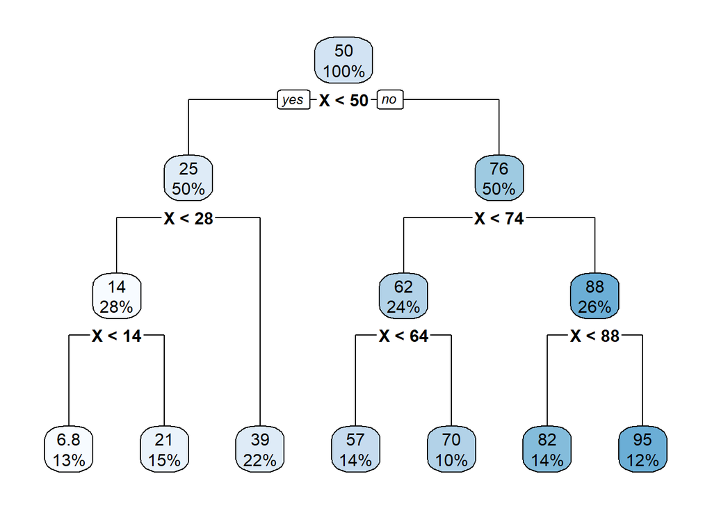

```r
k <- 1
N <- 100

X <- matrix(seq(1, 100, 1))
B <- rep(1, k)
e <- matrix(rnorm(n=1*N, mean=0, sd=1), N, 1)

Y <- X %*% B + e

tree <- rpart(Y ~ X, data=data.frame(X))
rpart.plot(tree)
```

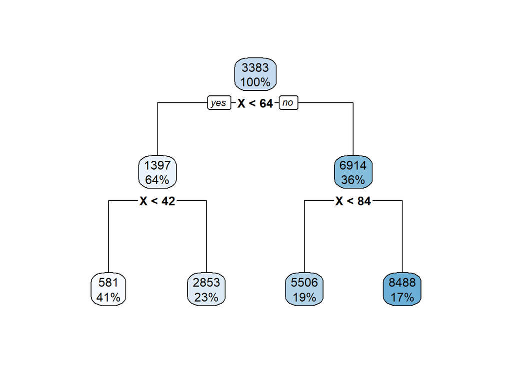

```r
Y2 <- X^2 %*% B + e

tree2 <- rpart(Y2 ~ X^2, data=data.frame(X))
rpart.plot(tree2)
```

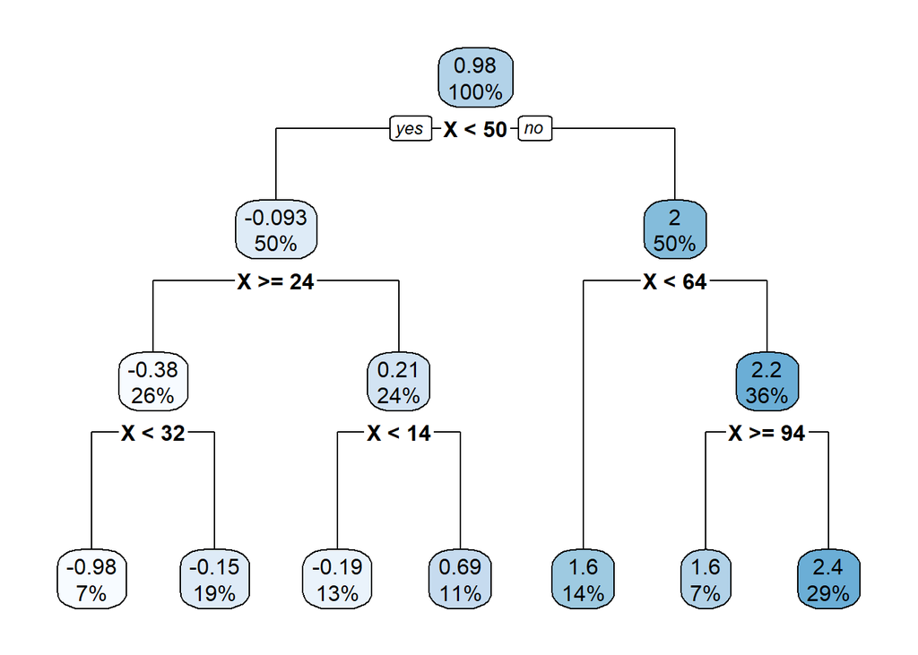

```r
x_new <-
  data.frame(X) %>%
  mutate(x_greater_than_50=(X>50))

Y3 <- 2 * x_new$x_greater_than_50 + e

tree3 <- rpart(Y3 ~ ., data=x_new)
rpart.plot(tree3)
```

```r
y_hat <- predict(tree3, newdata = x_new)

mse <- mean((Y3-y_hat)^2)
mse
```

```
## [1] 0.9245383
```

```r
new_x <- model.matrix(Y ~ X + X^2 + X^3, data=data.frame(X))
lasso <- cv.glmnet(new_x, Y, alpha=1)

y_hat <- predict(lasso, newx = new_x)

mse <- mean((Y3-y_hat)^2)
mse
```

```
## [1] 3211.276
```